# AIPND_image_classifier_project

## AI Programming with Python Nanodegree: Image Classifier Project

- Do not make changes to the first 2 code cells, they are being used for setting up the `flowers` dataset and `cat_to_name.json`. Start writing code from third code cell onwards.
- To use this notebook: `File > Save a copy in Drive`

### Code Explanation:

- **Setting Up Flower Dataset:**
  - `data_dir = './flowers'`: Defines the directory path for the flower dataset.
  - `FLOWERS_DIR = Path(data_dir)`: Uses `Path` from `pathlib` for handling PosixPath.
- **Downloading and Extracting Dataset:**
  - `if not FLOWERS_DIR.is_dir()`: Checks if the dataset directory exists.
    - `FLOWERS_DIR.mkdir(parents=True, exist_ok=True)`: Creates the directory if not present.
  - `TARBALL = FLOWERS_DIR / "flower_data.tar.gz"`: Defines the tarball path.
  - Downloads and extracts the dataset if not already present:
    - `request = requests.get(...)`: Downloads the 'flower_data.tar.gz' file.
    - `with open(TARBALL, "wb") as file_ref`: Writes the downloaded content to the tarball.
    - `with tarfile.open(TARBALL, "r") as tar_ref`: Extracts the tarball contents to the dataset directory.
- **Cleaning Up:**
  - `os.remove(TARBALL)`: Deletes the downloaded tarball to save space.
- **Status Messages:**
  - Prints informative messages about the directory creation, download, extraction, and cleanup.

```python
# imports
import os
import requests
from pathlib import Path
import tarfile

# defining dataset directory
data_dir = './flowers'

# using pathlib.Path for handling PosixPath
FLOWERS_DIR = Path(data_dir)

# downloading and setting up data if not already present
if not FLOWERS_DIR.is_dir():
    # creating directory
    FLOWERS_DIR.mkdir(parents=True, exist_ok=True)
    print(f"[INFO] Directory created: ./{FLOWERS_DIR}")

    print() # for readability

    # tarball path
    TARBALL = FLOWERS_DIR / "flower_data.tar.gz"

    # downloading and writing the tarball to './flowers' directory
    print(f"[INFO] Downloading the file 'flower_data.tar.gz' to ./{FLOWERS_DIR}")
    request = requests.get('https://s3.amazonaws.com/content.udacity-data.com/nd089/flower_data.tar.gz')
    with open(TARBALL, "wb") as file_ref:
        file_ref.write(request.content)
        print(f"[INFO] 'flower_data.tar.gz' saved to ./{FLOWERS_DIR}")

    print() # for readability

    # extracting the downloaded tarball
    print(f"[INFO] Extracting the downloaded tarball to ./{FLOWERS_DIR}")
    with tarfile.open(TARBALL, "r") as tar_ref:
        tar_ref.extractall(FLOWERS_DIR)
        print(f"[INFO] 'flower_data.tar.gz' extracted successfully to ./{FLOWERS_DIR}")

    print() # for readability

    # using os.remove to delete the downloaded tarball
    print("[INFO] Deleting the tarball to save space.")
    os.remove(TARBALL)
else:
    print(f"[INFO] Dataset already setup at ./{FLOWERS_DIR}")
```

```
[INFO] Directory created: ./flowers

[INFO] Downloading the file 'flower_data.tar.gz' to ./flowers
[INFO] 'flower_data.tar.gz' saved to ./flowers

[INFO] Extracting the downloaded tarball to ./flowers
[INFO] 'flower_data.tar.gz' extracted successfully to ./flowers

[INFO] Deleting the tarball to save space.
```

### Code Explanation:

- **Creating a JSON File for Flower Categories:**
  - `data`: Defines a dictionary containing numerical keys and corresponding flower names.
  - `with open('cat_to_name.json', 'w') as file`: Opens the file 'cat_to_name.json' for writing.
  - `json.dump(data, file)`: Writes the dictionary data to the JSON file.
- **Interpreting the Output:**
  - The code creates a JSON file named 'cat_to_name.json' that serves as a mapping between numerical keys and flower names. This mapping can be useful for associating numerical labels with human-readable names in machine learning tasks.

```python
import json

data = {
    "21": "fire lily", "3": "canterbury bells", "45": "bolero deep blue", "1": "pink primrose", "34": "mexican aster",
    "27": "prince of wales feathers", "7": "moon orchid", "16": "globe-flower", "25": "grape hyacinth", "26": "corn poppy",
    "79": "toad lily", "39": "siam tulip", "24": "red ginger", "67": "spring crocus", "35": "alpine sea holly",
    "32": "garden phlox", "10": "globe thistle", "6": "tiger lily", "93": "ball moss", "33": "love in the mist",
    "9": "monkshood", "102": "blackberry lily", "14": "spear thistle", "19": "balloon flower", "100": "blanket flower",
    "13": "king protea", "49": "oxeye daisy", "15": "yellow iris", "61": "cautleya spicata", "31": "carnation",
    "64": "silverbush", "68": "bearded iris", "63": "black-eyed susan", "69": "windflower", "62": "japanese anemone",
    "20": "giant white arum lily", "38": "great masterwort", "4": "sweet pea", "86": "tree mallow",
    "101": "trumpet creeper", "42": "daffodil", "22": "pincushion flower", "2": "hard-leaved pocket orchid",
    "54": "sunflower", "66": "osteospermum", "70": "tree poppy", "85": "desert-rose", "99": "bromelia", "87": "magnolia",
    "5": "english marigold", "92": "bee balm", "28": "stemless gentian", "97": "mallow", "57": "gaura",
    "40": "lenten rose", "47": "marigold", "59": "orange dahlia", "48": "buttercup", "55": "pelargonium",
    "36": "ruby-lipped cattleya", "91": "hippeastrum", "29": "artichoke", "71": "gazania", "90": "canna lily",
    "18": "peruvian lily", "98": "mexican petunia", "8": "bird of paradise", "30": "sweet william",
    "17": "purple coneflower", "52": "wild pansy", "84": "columbine", "12": "colt's foot", "11": "snapdragon",
    "96": "camellia", "23": "fritillary", "50": "common dandelion", "44": "poinsettia", "53": "primula",
    "72": "azalea", "65": "californian poppy", "80": "anthurium", "76": "morning glory", "37": "cape flower",
    "56": "bishop of llandaff", "60": "pink-yellow dahlia", "82": "clematis", "58": "geranium", "75": "thorn apple",
    "41": "barbeton daisy", "95": "bougainvillea", "43": "sword lily", "83": "hibiscus", "78": "lotus lotus",
    "88": "cyclamen", "94": "foxglove", "81": "frangipani", "74": "rose", "89": "watercress", "73": "water lily",
    "46": "wallflower", "77": "passion flower", "51": "petunia"
}

with open('cat_to_name.json', 'w') as file:
    json.dump(data, file)
```

```python
# Check torch version and CUDA status if GPU is enabled.
import torch
print(torch.__version__)
print(torch.cuda.is_available()) # Should return True when GPU is enabled.
```

```
2.5.1+cu124
True
```

```python
import torch
import torch.nn.functional as F
import numpy as np
import matplotlib.pyplot as plt
import time
from torch import nn
from torch import optim
from PIL import Image
from collections import OrderedDict
from torchvision import datasets, transforms, models
```

```python
data_dir = 'flowers'
train_dir = data_dir + '/train'
valid_dir = data_dir + '/valid'
test_dir = data_dir + '/test'
```

```python
# TODO: Define your transforms for the training, validation, and testing sets
data_transforms = {'training': transforms.Compose([transforms.RandomRotation(30),
                                                transforms.RandomResizedCrop(224),
                                                transforms.RandomHorizontalFlip(),
                                                transforms.ToTensor(),
                                                transforms.Normalize([0.485, 0.456, 0.406], [0.229, 0.224, 0.225])]),
                   'validation': transforms.Compose([transforms.Resize(256),
                                                transforms.CenterCrop(224),
                                                transforms.ToTensor(),
                                                transforms.Normalize([0.485, 0.456, 0.406], [0.229, 0.224, 0.225])]),
                   'testing': transforms.Compose([transforms.Resize(256),
                                               transforms.CenterCrop(224),
                                               transforms.ToTensor(),
                                               transforms.Normalize([0.485, 0.456, 0.406], [0.229, 0.224, 0.225])])
                   }

# TODO: Load the datasets with ImageFolder
image_datasets = {
    'training': datasets.ImageFolder(train_dir, transform=data_transforms['training']),
    'validation': datasets.ImageFolder(valid_dir, transform=data_transforms['validation']),
    'testing': datasets.ImageFolder(test_dir, transform=data_transforms['testing'])
}
# TODO: Using the image datasets and the trainforms, define the dataloaders
# dataloaders = {
#     'training': torch.utils.data.DataLoader(image_datasets['training'], batch_size=32, shuffle=True),
#     'validation': torch.utils.data.DataLoader(image_datasets['validation'], batch_size=32, shuffle=False),
#     'testing': torch.utils.data.DataLoader(image_datasets['testing'], batch_size=32, shuffle=False)
# }

dataloaders = {x: torch.utils.data.DataLoader(image_datasets[x], batch_size=32, shuffle=True) for x in ['training', 'validation', 'testing']}
```

```python
import json

with open('cat_to_name.json', 'r') as f:
    cat_to_name = json.load(f)
```

```python
# TODO: Build and train your network
model = models.vgg13(pretrained=True)
model
```

```
VGG(
  (features): Sequential(
    (0): Conv2d(3, 64, kernel_size=(3, 3), stride=(1, 1), padding=(1, 1))
    (1): ReLU(inplace=True)
    (2): Conv2d(64, 64, kernel_size=(3, 3), stride=(1, 1), padding=(1, 1))
    (3): ReLU(inplace=True)
    (4): MaxPool2d(kernel_size=2, stride=2, padding=0, dilation=1, ceil_mode=False)
    (5): Conv2d(64, 128, kernel_size=(3, 3), stride=(1, 1), padding=(1, 1))
    (6): ReLU(inplace=True)
    (7): Conv2d(128, 128, kernel_size=(3, 3), stride=(1, 1), padding=(1, 1))
    (8): ReLU(inplace=True)
    (9): MaxPool2d(kernel_size=2, stride=2, padding=0, dilation=1, ceil_mode=False)
    (10): Conv2d(128, 256, kernel_size=(3, 3), stride=(1, 1), padding=(1, 1))
    (11): ReLU(inplace=True)
    (12): Conv2d(256, 256, kernel_size=(3, 3), stride=(1, 1), padding=(1, 1))
    (13): ReLU(inplace=True)
    (14): MaxPool2d(kernel_size=2, stride=2, padding=0, dilation=1, ceil_mode=False)
    (15): Conv2d(256, 512, kernel_size=(3, 3), stride=(1, 1), padding=(1, 1))
    (16): ReLU(inplace=True)
    (17): Conv2d(512, 512, kernel_size=(3, 3), stride=(1, 1), padding=(1, 1))
    (18): ReLU(inplace=True)
    (19): MaxPool2d(kernel_size=2, stride=2, padding=0, dilation=1, ceil_mode=False)
    (20): Conv2d(512, 512, kernel_size=(3, 3), stride=(1, 1), padding=(1, 1))
    (21): ReLU(inplace=True)
    (22): Conv2d(512, 512, kernel_size=(3, 3), stride=(1, 1), padding=(1, 1))
    (23): ReLU(inplace=True)
    (24): MaxPool2d(kernel_size=2, stride=2, padding=0, dilation=1, ceil_mode=False)
  )
  (avgpool): AdaptiveAvgPool2d(output_size=(7, 7))
  (classifier): Sequential(
    (0): Linear(in_features=25088, out_features=4096, bias=True)
    (1): ReLU(inplace=True)
    (2): Dropout(p=0.5, inplace=False)
    (3): Linear(in_features=4096, out_features=4096, bias=True)
    (4): ReLU(inplace=True)
    (5): Dropout(p=0.5, inplace=False)
    (6): Linear(in_features=4096, out_features=1000, bias=True)
  )
)
```

```python
# TODO: Do validation on the test set

#freeze the parameters
for param in model.parameters():
    param.requires_grad = False

# feed forward network

classifier = nn.Sequential(OrderedDict([
    ('fc1', nn.Linear(25088, 512)),  # First hidden layer: 512 neurons
    ('relu1', nn.ReLU()),            # ReLU activation

    ('fc2', nn.Linear(512, 256)),    # Second hidden layer: 256 neurons
    ('relu2', nn.ReLU()),            # ReLU activation

    ('fc3', nn.Linear(256, 102)),    # Output layer: 102 neurons
    ('output', nn.LogSoftmax(dim=1)) # LogSoftmax for classification
]))
# pass the classifier to the pre-trained model
model.classifier = classifier

# train it
criterion = nn.NLLLoss()
optimizer = optim.AdamW(model.classifier.parameters(), lr=0.001)
```

```python
epochs = 5
# model.to('cuda')
device = torch.device("cuda" if torch.cuda.is_available() else "cpu")
model.to(device)


for e in range(epochs):

    for dataset in ['training', 'validation']:
        if dataset == 'training':
            model.train()
        else:
            model.eval()

        running_loss = 0.0
        running_accuracy = 0

        for inputs, labels in dataloaders[dataset]:

            inputs, labels = inputs.to(device), labels.to(device)
            optimizer.zero_grad()

            # Forward
            with torch.set_grad_enabled(dataset == 'training'):
                outputs = model(inputs)
                _, preds = torch.max(outputs, 1)
                loss = criterion(outputs, labels)

                # Backward
                if dataset == 'training':
                    loss.backward()
                    optimizer.step()

            running_loss += loss.item() * inputs.size(0)
            running_accuracy += torch.sum(preds == labels.data)

        dataset_sizes = {x: len(image_datasets[x]) for x in ['training', 'validation', 'testing']}
        epoch_loss = running_loss / dataset_sizes[dataset]
        epoch_accuracy = running_accuracy.double() / dataset_sizes[dataset]

        print("Epoch: {}/{}... ".format(e+1, epochs),
              "{} Loss: {:.4f}    Accurancy: {:.4f}".format(dataset, epoch_loss, epoch_accuracy))
```

```
Epoch: 1/5...  training Loss: 2.3734    Accurancy: 0.4350
Epoch: 1/5...  validation Loss: 0.9168    Accurancy: 0.7372
Epoch: 2/5...  training Loss: 1.0930    Accurancy: 0.7027
Epoch: 2/5...  validation Loss: 0.6996    Accurancy: 0.8068
Epoch: 3/5...  training Loss: 0.8800    Accurancy: 0.7619
Epoch: 3/5...  validation Loss: 0.6227    Accurancy: 0.8399
Epoch: 4/5...  training Loss: 0.7677    Accurancy: 0.7888
Epoch: 4/5...  validation Loss: 0.5687    Accurancy: 0.8509
Epoch: 5/5...  training Loss: 0.7187    Accurancy: 0.7952
Epoch: 5/5...  validation Loss: 0.4843    Accurancy: 0.8753
```

```python
# validation on the test set
def check_accuracy_on_test(test_loader):
    correct = 0
    total = 0
    device = torch.device("cuda" if torch.cuda.is_available() else "cpu")
    model.to(device)
    with torch.no_grad():
        for data in test_loader:
            images, labels = data
            images, labels = images.to(device), labels.to(device)
            outputs = model(images)
            _, predicted = torch.max(outputs.data, 1)
            total += labels.size(0)
            correct += (predicted == labels).sum().item()

    print('Accuracy of the network on the test images: %d %%' % (100 * correct / total))
```

```python
check_accuracy_on_test(dataloaders['training'])
```

```
Accuracy of the network on the test images: 83 %
```

```python
# TODO: Save the checkpoint
model.class_to_idx = image_datasets['training'].class_to_idx
model.cpu()
torch.save({'model': 'vgg13',
            'state_dict': model.state_dict(),
            'class_to_idx': model.class_to_idx},
            'save_checkpoint.pth')
```

```python
# TODO: Write a function that loads a checkpoint and rebuilds the model
def loading_model(checkpoint_path):

    check_path = torch.load(checkpoint_path)

    model = models.vgg13(pretrained=True)
    for param in model.parameters():
        param.requires_grad = False

    model.class_to_idx = check_path['class_to_idx']

    # Build a feed-forward network
    # classifier = nn.Sequential(OrderedDict([('fc1', nn.Linear(25088, 4096)),
    #                                         ('relu', nn.ReLU()),
    #                                         ('dropout1',nn.Dropout(0.2)),
    #                                         ('fc2', nn.Linear(4096, 102)),
    #                                         ('output', nn.LogSoftmax(dim=1))]))
    classifier = nn.Sequential(OrderedDict([
    ('fc1', nn.Linear(25088, 512)),  # First hidden layer: 512 neurons
    ('relu1', nn.ReLU()),            # ReLU activation

    ('fc2', nn.Linear(512, 256)),    # Second hidden layer: 256 neurons
    ('relu2', nn.ReLU()),            # ReLU activation

    ('fc3', nn.Linear(256, 102)),    # Output layer: 102 neurons
    ('output', nn.LogSoftmax(dim=1)) # LogSoftmax for classification
]))

    # Put the classifier on the pretrained network
    model.classifier = classifier
    model.load_state_dict(check_path['state_dict'])

    return model
```

```python
model = loading_model('save_checkpoint.pth')
model
```

```
VGG(
  (features): Sequential(
    (0): Conv2d(3, 64, kernel_size=(3, 3), stride=(1, 1), padding=(1, 1))
    (1): ReLU(inplace=True)
    (2): Conv2d(64, 64, kernel_size=(3, 3), stride=(1, 1), padding=(1, 1))
    (3): ReLU(inplace=True)
    (4): MaxPool2d(kernel_size=2, stride=2, padding=0, dilation=1, ceil_mode=False)
    (5): Conv2d(64, 128, kernel_size=(3, 3), stride=(1, 1), padding=(1, 1))
    (6): ReLU(inplace=True)
    (7): Conv2d(128, 128, kernel_size=(3, 3), stride=(1, 1), padding=(1, 1))
    (8): ReLU(inplace=True)
    (9): MaxPool2d(kernel_size=2, stride=2, padding=0, dilation=1, ceil_mode=False)
    (10): Conv2d(128, 256, kernel_size=(3, 3), stride=(1, 1), padding=(1, 1))
    (11): ReLU(inplace=True)
    (12): Conv2d(256, 256, kernel_size=(3, 3), stride=(1, 1), padding=(1, 1))
    (13): ReLU(inplace=True)
    (14): MaxPool2d(kernel_size=2, stride=2, padding=0, dilation=1, ceil_mode=False)
    (15): Conv2d(256, 512, kernel_size=(3, 3), stride=(1, 1), padding=(1, 1))
    (16): ReLU(inplace=True)
    (17): Conv2d(512, 512, kernel_size=(3, 3), stride=(1, 1), padding=(1, 1))
    (18): ReLU(inplace=True)
    (19): MaxPool2d(kernel_size=2, stride=2, padding=0, dilation=1, ceil_mode=False)
    (20): Conv2d(512, 512, kernel_size=(3, 3), stride=(1, 1), padding=(1, 1))
    (21): ReLU(inplace=True)
    (22): Conv2d(512, 512, kernel_size=(3, 3), stride=(1, 1), padding=(1, 1))
    (23): ReLU(inplace=True)
    (24): MaxPool2d(kernel_size=2, stride=2, padding=0, dilation=1, ceil_mode=False)
  )
  (avgpool): AdaptiveAvgPool2d(output_size=(7, 7))
  (classifier): Sequential(
    (fc1): Linear(in_features=25088, out_features=512, bias=True)
    (relu1): ReLU()
    (fc2): Linear(in_features=512, out_features=256, bias=True)
    (relu2): ReLU()
    (fc3): Linear(in_features=256, out_features=102, bias=True)
    (output): LogSoftmax(dim=1)
  )
)
```

```python
def process_image(image):
    ''' Scales, crops, and normalizes a PIL image for a PyTorch model,
        returns an Numpy array
    '''

    # TODO: Process a PIL image for use in a PyTorch model
    pil_image = Image.open(image)

    # Edit Images
    edit_image = transforms.Compose([transforms.Resize(256),
                                     transforms.RandomCrop(224),
                                     transforms.ToTensor(),
                                     transforms.Normalize(mean=[0.485, 0.456, 0.406], std=[0.229, 0.224, 0.225])])

    # Images Dimensions
    img_tensor = edit_image(pil_image)
    processed_image = np.array(img_tensor)
    processed_image = processed_image.transpose((0, 2, 1))

    return processed_image
```

```python
# Test images
image_path = 'flowers/test/1/image_06743.jpg'
img = process_image(image_path)
print(img.shape)
```

```
(3, 224, 224)
```

```python
def imshow(image, ax=None, title=None):
    """Imshow for Tensor."""
    if ax is None:
        fig, ax = plt.subplots()
    if title:
        plt.title(title)

    # PyTorch tensors assume the color channel is the first dimension
    # but matplotlib assumes is the third dimension
    image = image.transpose((1, 2, 0))

    # Undo preprocessing
    mean = np.array([0.485, 0.456, 0.406])
    std = np.array([0.229, 0.224, 0.225])
    image = std * image + mean
    # image = std[None, None, :] * image + mean[None, None, :]

    # Image needs to be clipped between 0 and 1 or it looks like noise when displayed
    image = np.clip(image, 0, 1)

    ax.imshow(image)

    return ax
```

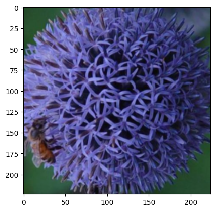

```python
imshow(process_image("flowers/test/10/image_07090.jpg"));
```

```python
def predict(image_path, model, topk=5):
    ''' Predict the class (or classes) of an image using a trained deep learning model.
    '''

    # TODO: Implement the code to predict the class from an image file
    model.class_to_idx = image_datasets['training'].class_to_idx
    # model.to('cuda')
    device = torch.device("cuda" if torch.cuda.is_available() else "cpu")
    model.to(device)

    img_torch = process_image(image_path)  # Returns a NumPy array
    img_torch = torch.from_numpy(img_torch).type(torch.FloatTensor)  # Convert to tensor
    img_torch = img_torch.unsqueeze(0).to(device)  # Add batch dimension & move to correct device


    # img_torch = process_image(image_path)
    # img_torch = torch.from_numpy(img_torch).type(torch.FloatTensor)
    # img_torch = img_torch.unsqueeze(0)
    # img_torch = img_torch.float()

    with torch.no_grad():
        # output = model.forward(img_torch.cuda())
        output = model.forward(img_torch)

    probability = F.softmax(output.data,dim=1)
    probabilies = probability.topk(topk)
    # score = np.array(probabilies[0][0]).cpu().numpy()
    score = probabilies[0][0].cpu().numpy()
    index = probabilies[1][0].cpu().numpy()
    # flowers_list = [cat_to_name[str(index + 1)] for index in np.array(probabilies[1][0])]
    flowers_list = [cat_to_name[str(i)] for i in index]

    return score, flowers_list
```

```python
# TODO: Display an image along with the top 5 classes
def display_top(image_path, model):

    # Setting plot area
    plt.figure(figsize = (3,6))
    ax = plt.subplot(2,1,1)

    # Display test flower
    img = process_image(image_path)
    get_title  = image_path.split('/')
    print(cat_to_name[get_title[2]])
    imshow(img, ax, title = cat_to_name[get_title[2]]);

    # Making prediction
    score, flowers_list = predict(image_path, model)
    fig,ax = plt.subplots(figsize=(4,3))
    sticks = np.arange(len(flowers_list))
    ax.barh(sticks, score, height=0.3, linewidth=2.0, align = 'center')
    ax.set_yticks(ticks = sticks)
    ax.set_yticklabels(flowers_list)
```

```
stemless gentian
blanket flower
yellow iris
grape hyacinth
```

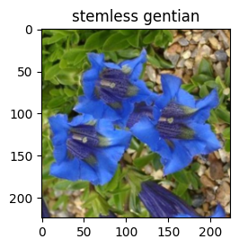

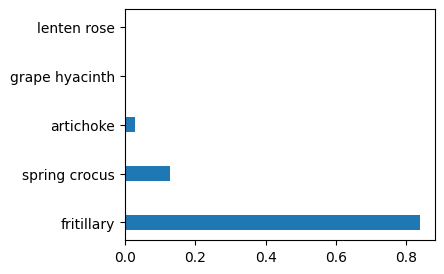

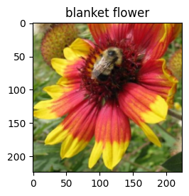

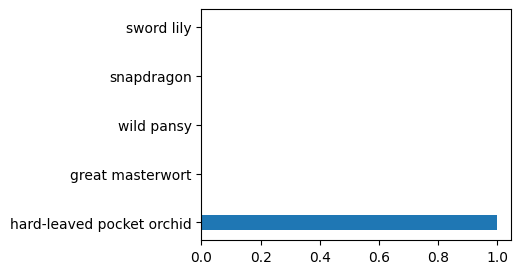

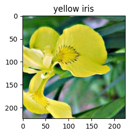

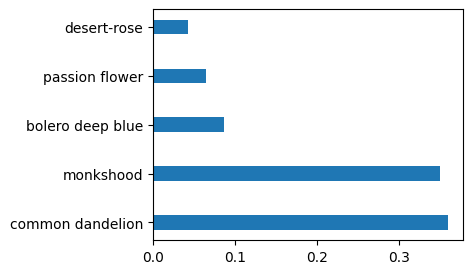

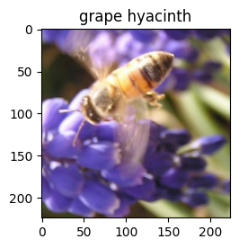

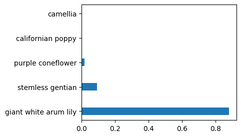

```python
images_paths = ['flowers/test/28/image_05214.jpg',
                'flowers/test/100/image_07896.jpg',
                'flowers/test/15/image_06351.jpg',
                'flowers/test/25/image_06583.jpg']
for i in images_paths:
    display_top(i, model)
```

```python
# TODO remove .pth files or move it to a temporary `~/opt` directory in this Workspace
# !rm save_checkpoint.pth
```